# Finalproject

### Scatter plot

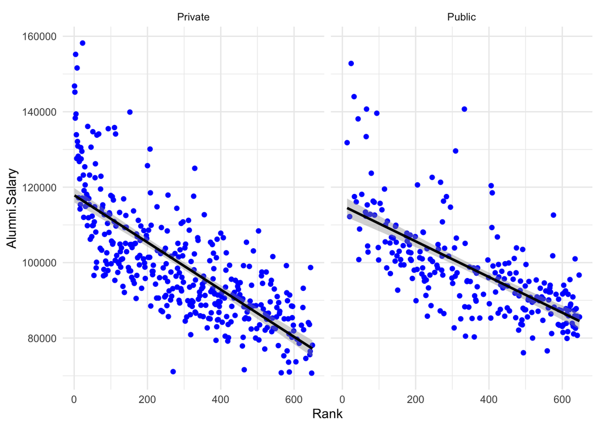

```r
ggplot(collegesize, aes(x=Rank, y = Alumni.Salary))+
  geom_point(color="blue")+
  facet_wrap( ~ Public.Private)+
  geom_smooth(method = "lm", linetype=1, color="black") +
  theme_minimal()
```

In this graph we can see that for public and private universities the trend is the same that as the average alumni salary rises the rank of the college gets lower. This would make sense because it is suggesting that the lower ranked schools, or “better” schools have alumni that makes a higher salary. The trend seems to be a little bit more extreme as the angle is steeper in private universities.

### Scatter plot

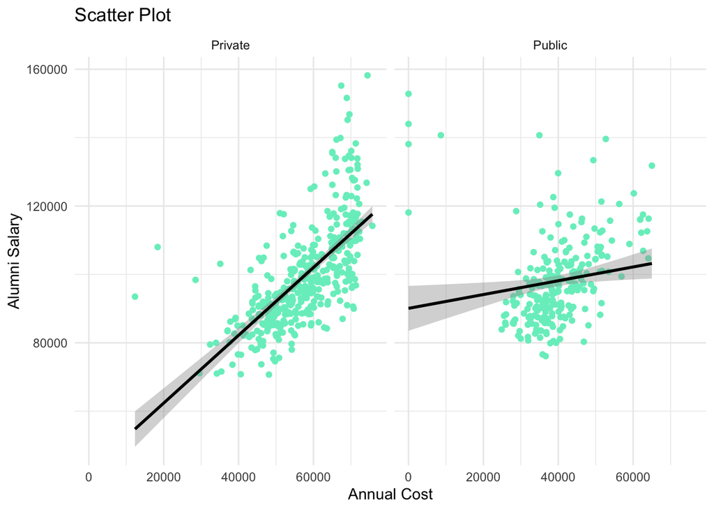

```r
ggplot(collegesize, aes(x= Total.Annual.Cost, y = Alumni.Salary))+
  geom_point(color = "aquamarine2") +
  facet_wrap(~ Public.Private) +
  ggtitle("Scatter Plot") + xlab("Annual Cost") + ylab("Alumni Salary") +
    geom_smooth(method = "lm", linetype=1, color="black") +
  theme_minimal()
```

This line graph is showing that as the annual cost of schools increases so does the average alumni salary. Looking at the two graphs, we can see that there is a clear correlation between alumni salary and annual cost for private schools and not nearly as much of a correlation between the two with public schools. We think that this makes sense because at private schools the networking opportunities are very good and opportunities are sometimes limited to just those private schools students. Something that is also important to note is that instate public schools lost much less than private schools annually. Whereas for public schools, instate and out of state tuition does not change.